# Bellabeat - Google Data Analytics case study

Gabriele Angioletti

2024-02-19

# Scenario

You are a junior data analyst working on the marketing analyst team at Bellabeat, a high-tech manufacturer of health-focused products for women. Bellabeat is a successful small company, but they have the potential to become a larger player in the global smart device market. Urška Sršen, cofounder and Chief Creative officer of Bellabeat, believes that analyzing smart device fitness data could help unlock new growth opportunities for the company. You have been asked to focus on one of Bellabeat’s products and analyze smart device data to gain insight into how consumers are using their smart devices. The insights you discover will then help guide marketing strategy for the company. You will present your analysis to the Bellabeat executive team along with your high-level recommendations for Bellabeat’s marketing strategy.

### Definition of the business task.

Identify opportunities to improve Bellabeat’s marketing strategy through the analysis of smart devices usage.

### Stakeholders and application of the results

The main stakeholders are the Chief creative officer, Miss Srsen, the executive team and the marketing team. The findings of the analysis could be used to introduce or improve the ways customers use Bellabeat’s devices and the ways such value is communicated by the marketing team.

### Description of all data sources used

The only data source used is FitBit Fitness Tracker Data. The data has been retrived from Kaggle and was made available through Mobius, I downloaded it and stored in my computer. [Go to the dataset](https://www.kaggle.com/datasets/arashnic/fitbit/data). The data is open source under the licence CC0, so it’s of public domain and no copyright applies to it. According to the provider, “this dataset generated by respondents to a distributed survey via Amazon Mechanical Turk between 03.12.2016-05.12.2016. Thirty eligible Fitbit users consented to the submission of personal tracker data, including minute-level output for physical activity, heart rate, and sleep monitoring.” It consists of 18 .csv files. Data about steps, sleep, activity, calories, intensities per minute, per hour and per day.

The sample is limited to 33 people at most and lacks any information about the population, the risk of encountering bias is high. It was collected 8 years ago and is far from being comprehensive. The data integrity is not solid enough for the results to meet scientific standards and also gaining statistically significant insight could be challenging.

### Analysis process: description

I chose to carry out this project using exclusively R, to explore the wide range of possible actions that this language and its packages provide. After defining the business task and checking all the resources available (as done above), a data analyst should plan its analysis step by step. First of all the data needs to be prepared and processed. Then it can be analyzed and visualized, so that the insights are ready to be shared with stakeholders. Most times analysts are also required to act on their findings and find ways to apply them to the business.

# Prepare and process the data

The following steps are carried out in R Studio.

The first step is to load useful packages.

```r
library(dplyr)
library(tidyverse)
library(ggplot2)
library(lubridate)
library(tidyr)
library(janitor)
library(here)
library(skimr)
```

A quick look at the data.

It is necessary to have a quick look at the datasets and identify the ones that best could serve my purpose. The data collected daily seems to be the best to start the analysis. I identified 6 tables. Let’s assign them to variables.

```r
sleep_raw <- read_csv("sleepDay_merged.csv")
weight_raw <- read_csv("weightLogInfo_merged.csv")
calories_raw <- read_csv("dailyCalories_merged.csv")
intensities_raw <- read_csv("dailyIntensities_merged.csv")
steps_raw <- read_csv("dailySteps_merged.csv")
activity_raw <- read_csv("dailyActivity_merged.csv")
```

Let’s check that the data was imported correctly.

Let’s check the first rows and the data types using head() and that the , sample is big enough for the findings to be meaningful (recommended: >=30), using n_distinct() to count the unique IDs for each table.

Sleep

```r
head(sleep_raw)
```

```
## # A tibble: 6 × 5
##           Id SleepDay        TotalSleepRecords TotalMinutesAsleep TotalTimeInBed
##        <dbl> <chr>                       <dbl>              <dbl>          <dbl>
## 1 1503960366 4/12/2016 12:0…                 1                327            346
## 2 1503960366 4/13/2016 12:0…                 2                384            407
## 3 1503960366 4/15/2016 12:0…                 1                412            442
## 4 1503960366 4/16/2016 12:0…                 2                340            367
## 5 1503960366 4/17/2016 12:0…                 1                700            712
## 6 1503960366 4/19/2016 12:0…                 1                304            320
```

```r
n_distinct(sleep_raw$Id)
```

```
## [1] 24
```

Weight

```r
head(weight_raw)
```

```
## # A tibble: 6 × 8
##           Id Date       WeightKg WeightPounds   Fat   BMI IsManualReport   LogId
##        <dbl> <chr>         <dbl>        <dbl> <dbl> <dbl> <lgl>            <dbl>
## 1 1503960366 5/2/2016 …     52.6         116.    22  22.6 TRUE           1.46e12
## 2 1503960366 5/3/2016 …     52.6         116.    NA  22.6 TRUE           1.46e12
## 3 1927972279 4/13/2016…    134.          294.    NA  47.5 FALSE          1.46e12
## 4 2873212765 4/21/2016…     56.7         125.    NA  21.5 TRUE           1.46e12
## 5 2873212765 5/12/2016…     57.3         126.    NA  21.7 TRUE           1.46e12
## 6 4319703577 4/17/2016…     72.4         160.    25  27.5 TRUE           1.46e12
```

```r
n_distinct(weight_raw$Id)
```

```
## [1] 8
```

Calories

```r
head(calories_raw)
```

```
## # A tibble: 6 × 3
##           Id ActivityDay Calories
##        <dbl> <chr>          <dbl>
## 1 1503960366 4/12/2016       1985
## 2 1503960366 4/13/2016       1797
## 3 1503960366 4/14/2016       1776
## 4 1503960366 4/15/2016       1745
## 5 1503960366 4/16/2016       1863
## 6 1503960366 4/17/2016       1728
```

```r
n_distinct(calories_raw$Id)
```

```
## [1] 33
```

Intensities

```r
head(intensities_raw)
```

```
## # A tibble: 6 × 10
##         Id ActivityDay SedentaryMinutes LightlyActiveMinutes FairlyActiveMinutes
##      <dbl> <chr>                  <dbl>                <dbl>               <dbl>
## 1   1.50e9 4/12/2016                728                  328                  13
## 2   1.50e9 4/13/2016                776                  217                  19
## 3   1.50e9 4/14/2016               1218                  181                  11
## 4   1.50e9 4/15/2016                726                  209                  34
## 5   1.50e9 4/16/2016                773                  221                  10
## 6   1.50e9 4/17/2016                539                  164                  20
## # ℹ 5 more variables: VeryActiveMinutes <dbl>, SedentaryActiveDistance <dbl>,
## #   LightActiveDistance <dbl>, ModeratelyActiveDistance <dbl>,
## #   VeryActiveDistance <dbl>
```

```r
n_distinct(intensities_raw$Id)
```

```
## [1] 33
```

Steps

```r
head(steps_raw)
```

```
## # A tibble: 6 × 3
##           Id ActivityDay StepTotal
##        <dbl> <chr>           <dbl>
## 1 1503960366 4/12/2016       13162
## 2 1503960366 4/13/2016       10735
## 3 1503960366 4/14/2016       10460
## 4 1503960366 4/15/2016        9762
## 5 1503960366 4/16/2016       12669
## 6 1503960366 4/17/2016        9705
```

```r
n_distinct(steps_raw$Id)
```

```
## [1] 33
```

Activity

```r
head(activity_raw)
```

```
## # A tibble: 6 × 15
##           Id ActivityDate TotalSteps TotalDistance TrackerDistance
##        <dbl> <chr>             <dbl>         <dbl>           <dbl>
## 1 1503960366 4/12/2016         13162          8.5             8.5
## 2 1503960366 4/13/2016         10735          6.97            6.97
## 3 1503960366 4/14/2016         10460          6.74            6.74
## 4 1503960366 4/15/2016          9762          6.28            6.28
## 5 1503960366 4/16/2016         12669          8.16            8.16
## 6 1503960366 4/17/2016          9705          6.48            6.48
## # ℹ 10 more variables: LoggedActivitiesDistance <dbl>,
## #   VeryActiveDistance <dbl>, ModeratelyActiveDistance <dbl>,
## #   LightActiveDistance <dbl>, SedentaryActiveDistance <dbl>,
## #   VeryActiveMinutes <dbl>, FairlyActiveMinutes <dbl>,
## #   LightlyActiveMinutes <dbl>, SedentaryMinutes <dbl>, Calories <dbl>
```

```r
n_distinct(activity_raw$Id)
```

```
## [1] 33
```

The table weight_raw only has 8 unique IDs, making the sample size too small for any finding obtained to be meaningful. Similar considerations could be made about the sleep_raw table, as it does not reach the recommended minimum treshold of sample size >=30. As the other sample sizes are not much larger (24 vs 33) and having clear that findings coming from sleep_raw may not be considered statistically significant, I will still have a look at the table.

```r
remove(weight_raw)
```

I notice that sleep_raw’s column SleepDay is in a datetime format, with the time having no meaning as it is always “12:00:00”. I want to convert it to a date type column.

```r
sleep_raw$datetimesleep <- as.POSIXct(sleep_raw$SleepDay, format = "%m/%d/%Y %H:%M")
sleep_raw$date <- as.Date(sleep_raw$datetimesleep)
```

Let’s check the conversion succedeed and then remove SleepDay and datetimesleep.

```r
head(sleep_raw)
```

```
## # A tibble: 6 × 7
##           Id SleepDay        TotalSleepRecords TotalMinutesAsleep TotalTimeInBed
##        <dbl> <chr>                       <dbl>              <dbl>          <dbl>
## 1 1503960366 4/12/2016 12:0…                 1                327            346
## 2 1503960366 4/13/2016 12:0…                 2                384            407
## 3 1503960366 4/15/2016 12:0…                 1                412            442
## 4 1503960366 4/16/2016 12:0…                 2                340            367
## 5 1503960366 4/17/2016 12:0…                 1                700            712
## 6 1503960366 4/19/2016 12:0…                 1                304            320
## # ℹ 2 more variables: datetimesleep <dttm>, date <date>
```

```r
sleep_raw <- sleep_raw[, -2]
sleep_raw <- sleep_raw[, -5]
```

Everything worked perfectly, but the format of the date in this table is not consistent with the ones in the other tables. Let’s change it and make sure to delate the column in excess.

```r
sleep_raw$SleepDay <- format(sleep_raw$date, "%m/%d/%Y")
sleep_raw <- sleep_raw[, -5]
head(sleep_raw)
```

```
## # A tibble: 6 × 5
##           Id TotalSleepRecords TotalMinutesAsleep TotalTimeInBed SleepDay
##        <dbl>             <dbl>              <dbl>          <dbl> <chr>
## 1 1503960366                 1                327            346 04/12/2016
## 2 1503960366                 2                384            407 04/13/2016
## 3 1503960366                 1                412            442 04/15/2016
## 4 1503960366                 2                340            367 04/16/2016
## 5 1503960366                 1                700            712 04/17/2016
## 6 1503960366                 1                304            320 04/19/2016
```

I did not notice something, some data is redundant.

The table activity_raw is basically the merged result of the tables steps_raw, calories_raw and intensities_raw. I can therefore drop these three tables and focus on activity_raw.

```r
remove(steps_raw, calories_raw, intensities_raw)
```

It could therefore make sense to analyze data about calories, intensities and steps collected by hour, to have more detailed information.

Loading more data

```r
h_steps_raw <- read.csv("hourlySteps_merged.csv")
h_calories_raw <- read.csv("hourlyCalories_merged.csv")
h_intensities_raw <- read.csv("hourlyIntensities_merged.csv")
```

Let’s create a summary table, similar to activity raw, but by hour.

```r
hourly_summary <- merge(merge(h_steps_raw, h_calories_raw, by =
                                c("Id", "ActivityHour")), h_intensities_raw, by = c("Id", "ActivityHour"))
remove(h_calories_raw, h_steps_raw, h_intensities_raw)
head(hourly_summary)
```

```
##           Id          ActivityHour StepTotal Calories TotalIntensity
## 1 1503960366  4/12/2016 1:00:00 AM       160       61              8
## 2 1503960366  4/12/2016 1:00:00 PM       221       66              6
## 3 1503960366 4/12/2016 10:00:00 AM       676       99             29
## 4 1503960366 4/12/2016 10:00:00 PM        89       65              9
## 5 1503960366 4/12/2016 11:00:00 AM       360       76             12
## 6 1503960366 4/12/2016 11:00:00 PM       338       81             21
##   AverageIntensity
## 1         0.133333
## 2         0.100000
## 3         0.483333
## 4         0.150000
## 5         0.200000
## 6         0.350000
```

Let’s now split date and time and make the formats consistent.

```r
hourly_summary$ActivityHour=as.POSIXct(hourly_summary$ActivityHour, format="%m/%d/%Y %I:%M:%S %p", tz=Sys.timezone())
hourly_summary$time <- format(hourly_summary$ActivityHour, format = "%H:%M:%S")
hourly_summary$date <- format(hourly_summary$ActivityHour, format = "%m/%d/%Y")
hourly_summary <- hourly_summary[, -2]
head(hourly_summary)
```

```
##           Id StepTotal Calories TotalIntensity AverageIntensity     time
## 1 1503960366       160       61              8         0.133333 01:00:00
## 2 1503960366       221       66              6         0.100000 13:00:00
## 3 1503960366       676       99             29         0.483333 10:00:00
## 4 1503960366        89       65              9         0.150000 22:00:00
## 5 1503960366       360       76             12         0.200000 11:00:00
## 6 1503960366       338       81             21         0.350000 23:00:00
##         date
## 1 04/12/2016
## 2 04/12/2016
## 3 04/12/2016
## 4 04/12/2016
## 5 04/12/2016
## 6 04/12/2016
```

Let’s check if using summary() I get any insight on further cleaning that could be needed.

```r
activity_raw %>%
  select(-Id, -ActivityDate) %>%
  summary()
```

```
##    TotalSteps    TotalDistance    TrackerDistance  LoggedActivitiesDistance
##  Min.   :    0   Min.   : 0.000   Min.   : 0.000   Min.   :0.0000
##  1st Qu.: 3790   1st Qu.: 2.620   1st Qu.: 2.620   1st Qu.:0.0000
##  Median : 7406   Median : 5.245   Median : 5.245   Median :0.0000
##  Mean   : 7638   Mean   : 5.490   Mean   : 5.475   Mean   :0.1082
##  3rd Qu.:10727   3rd Qu.: 7.713   3rd Qu.: 7.710   3rd Qu.:0.0000
##  Max.   :36019   Max.   :28.030   Max.   :28.030   Max.   :4.9421
##  VeryActiveDistance ModeratelyActiveDistance LightActiveDistance
##  Min.   : 0.000     Min.   :0.0000           Min.   : 0.000
##  1st Qu.: 0.000     1st Qu.:0.0000           1st Qu.: 1.945
##  Median : 0.210     Median :0.2400           Median : 3.365
##  Mean   : 1.503     Mean   :0.5675           Mean   : 3.341
##  3rd Qu.: 2.053     3rd Qu.:0.8000           3rd Qu.: 4.782
##  Max.   :21.920     Max.   :6.4800           Max.   :10.710
##  SedentaryActiveDistance VeryActiveMinutes FairlyActiveMinutes
##  Min.   :0.000000        Min.   :  0.00    Min.   :  0.00
##  1st Qu.:0.000000        1st Qu.:  0.00    1st Qu.:  0.00
##  Median :0.000000        Median :  4.00    Median :  6.00
##  Mean   :0.001606        Mean   : 21.16    Mean   : 13.56
##  3rd Qu.:0.000000        3rd Qu.: 32.00    3rd Qu.: 19.00
##  Max.   :0.110000        Max.   :210.00    Max.   :143.00
##  LightlyActiveMinutes SedentaryMinutes    Calories
##  Min.   :  0.0        Min.   :   0.0   Min.   :   0
##  1st Qu.:127.0        1st Qu.: 729.8   1st Qu.:1828
##  Median :199.0        Median :1057.5   Median :2134
##  Mean   :192.8        Mean   : 991.2   Mean   :2304
##  3rd Qu.:264.0        3rd Qu.:1229.5   3rd Qu.:2793
##  Max.   :518.0        Max.   :1440.0   Max.   :4900
```

The columns LoggedActivitiesDistance and SedentaryActiveDistance feature a quite particular value structure, that seems to suggest the presence of some outliers strongly influencing the statistics about the values. I should take that into account when using these variables.

```r
hourly_summary %>%
  select(-Id, -date, -time) %>%
  summary()
```

```
##    StepTotal          Calories      TotalIntensity   AverageIntensity
##  Min.   :    0.0   Min.   : 42.00   Min.   :  0.00   Min.   :0.0000
##  1st Qu.:    0.0   1st Qu.: 63.00   1st Qu.:  0.00   1st Qu.:0.0000
##  Median :   40.0   Median : 83.00   Median :  3.00   Median :0.0500
##  Mean   :  320.2   Mean   : 97.39   Mean   : 12.04   Mean   :0.2006
##  3rd Qu.:  357.0   3rd Qu.:108.00   3rd Qu.: 16.00   3rd Qu.:0.2667
##  Max.   :10554.0   Max.   :948.00   Max.   :180.00   Max.   :3.0000
```

```r
sleep_raw %>%
  select(-Id, -SleepDay) %>%
  summary()
```

```
##  TotalSleepRecords TotalMinutesAsleep TotalTimeInBed
##  Min.   :1.000     Min.   : 58.0      Min.   : 61.0
##  1st Qu.:1.000     1st Qu.:361.0      1st Qu.:403.0
##  Median :1.000     Median :433.0      Median :463.0
##  Mean   :1.119     Mean   :419.5      Mean   :458.6
##  3rd Qu.:1.000     3rd Qu.:490.0      3rd Qu.:526.0
##  Max.   :3.000     Max.   :796.0      Max.   :961.0
```

Nothing unusual in hourly_summary and sleep_raw.

#### Let’s continue the cleaning routine

Cleaning column names and checking for NAs and duplicates.

First of all, it is a good idea to change the name columns SleepDay and ActivityDate into a more consistent “date”.

```r
activity_raw <- activity_raw %>%
  rename(date = ActivityDate)
sleep_raw <- sleep_raw %>%
  rename(date = SleepDay)
```

Now let’s convert the other column names to lower case as well.

```r
clean_names(activity_raw)
activity_raw <- rename_with(activity_raw, tolower)
clean_names(sleep_raw)
sleep_raw <- rename_with(sleep_raw, tolower)
clean_names(hourly_summary)
hourly_summary <- rename_with(hourly_summary, tolower)
```

Let’s deal with duplicates.

```r
sum(duplicated(activity_raw))
```

```
## [1] 0
```

```r
sum(duplicated(hourly_summary))
```

```
## [1] 0
```

```r
sum(duplicated(sleep_raw))
```

```
## [1] 3
```

Table sleep_raw seems to have 3 duplicates. Let’s remove them as well as NAs.

```r
sleep <- sleep_raw %>%
  distinct() %>%
  drop_na()
```

Let’s check if the duplicates were removed and consequently remove sleep_raw.

```r
if(sum(duplicated(sleep)) == 0) remove(sleep_raw)
```

Let’s drop NAs for the other tables as well

```r
activity <- activity_raw %>%
  drop_na()
remove(activity_raw)
hourly_summary <- hourly_summary %>%
  drop_na()
```

The columns “date” in each of the tables are in the incorrect data type “chr”. I need to fix this using as.Date().

```r
sleep$date <- as.Date(sleep$date, format = "%m/%d/%Y")
activity$date <- as.Date(activity$date, format = "%m/%d/%Y")
hourly_summary$date <- as.Date(hourly_summary$date, format = "%m/%d/%Y")
```

##### The cleaning process is basically over.

Some further transformation may still be useful

Let’s add a column representing the time asleep but in hours, as it makes it easier for most people to make sense of time.

```r
sleep <- sleep %>%
  mutate("hoursasleep" = totalminutesasleep/60)
head(sleep)
```

```
## # A tibble: 6 × 6
##           id totalsleeprecords totalminutesasleep totaltimeinbed date
##        <dbl>             <dbl>              <dbl>          <dbl> <date>
## 1 1503960366                 1                327            346 2016-04-12
## 2 1503960366                 2                384            407 2016-04-13
## 3 1503960366                 1                412            442 2016-04-15
## 4 1503960366                 2                340            367 2016-04-16
## 5 1503960366                 1                700            712 2016-04-17
## 6 1503960366                 1                304            320 2016-04-19
## # ℹ 1 more variable: hoursasleep <dbl>
```

I will now merge the tables sleep and activity by the columns id and date.

```r
daily_summary <- merge(sleep, activity, by = c("id", "date"))
```

I can now drop the table sleep as every row is matched in the new table.

```r
remove(sleep)
```

The same doesn’t apply to activity. I merged the two tables based on common columns only, therefore some observations available in activity were not inclued in the new table. I will therefore keep the source table, as I expect it to possibly be useful later.

# Analysis

## Relationship between hours of sleep and the amount of steps

As the first step, I would like to explore the relationship between the hours of sleep and the daily steps. If the correlation is strongly positive (close to 1), long sleepers are more likely to walk more. If it is strongly negative (close to -1), it means that people who sleep less tend to walk more.

```r
cor(daily_summary$totalsteps, daily_summary$hoursasleep)
```

```
## [1] -0.1903439
```

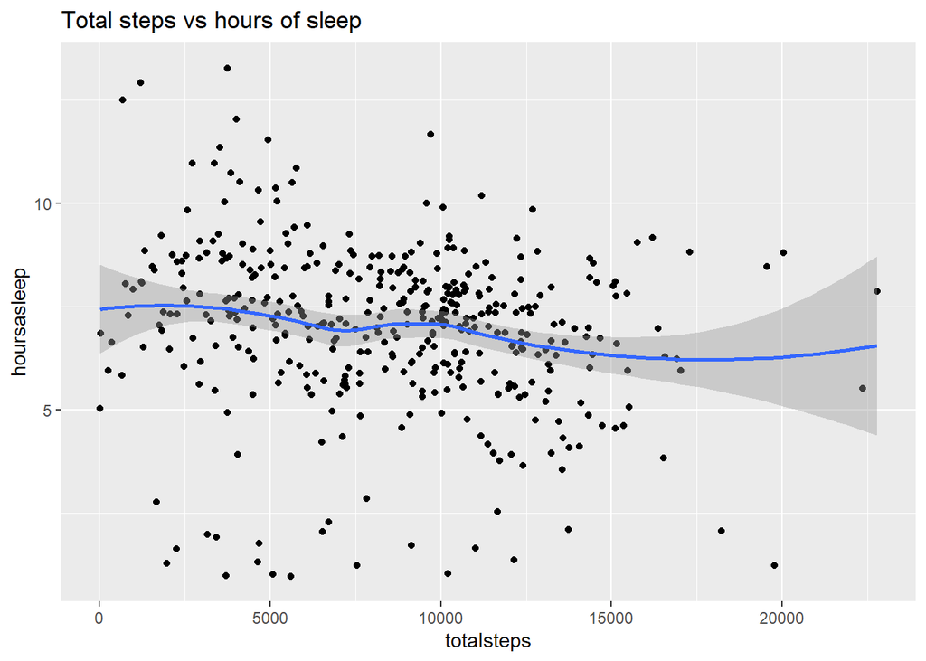

```r
steps_vs_sleep <- ggplot(daily_summary) + geom_point(mapping = aes(x = totalsteps, y = hoursasleep)) +
  geom_smooth(mapping = aes(x = totalsteps, y = hoursasleep))+
  labs(title = "Total steps vs hours of sleep")
print(steps_vs_sleep)
```

**The correlation is slightly negative. We can exlclude that people that sleep more walk more.**

Looking at the graph, I notice how people that sleep way above average are walking way less than average. I question how this is impacting the results.

I decide to divide the observations in three sleep_type groups: belowrecommended (<6.5 hours), recommended (between 6.5 and 9 hours) and aboverecommended (>9 hours). [Reference: Healthline.com](https://www.healthline.com/nutrition/how-much-sleep-you-need#TOC_TITLE_HDR_4)

I want to check how the average steps change between the groups.

```r
daily_summary <- daily_summary %>%
mutate(sleep_type = case_when(
  hoursasleep < 6.5 ~ "below",
  hoursasleep >= 6.5 & hoursasleep <= 9 ~ "recommended",
  hoursasleep > 9 ~ "above"
))
```

It could also be useful to know how many observations fall in each group.

```r
count_sleep <- daily_summary %>%
  count(sleep_type) %>%
  mutate(share_total = round(n/(sum(n)), 3))
print(count_sleep)
```

```
##    sleep_type   n share_total
## 1       above  39       0.095
## 2       below 136       0.332
## 3 recommended 235       0.573
```

Now let’s see the avereage steps per group and the correlation per group.

```r
sleep_type_summary <- daily_summary %>%
  group_by(sleep_type) %>%
  summarise(correlation = cor(totalsteps, hoursasleep), averagesteps =
              mean(totalsteps), averagesleep = mean(hoursasleep)) %>%
  arrange(averagesleep)
print(sleep_type_summary)
```

```
## # A tibble: 3 × 4
##   sleep_type  correlation averagesteps averagesleep
##   <chr>             <dbl>        <dbl>        <dbl>
## 1 below            0.0902        9532.         4.89
## 2 recommended     -0.0698        8306.         7.67
## 3 above           -0.410         6226.        10.2
```

The tables shows a negative correlation between hours of sleep and steps for where the sleep exceeds 9 hours. Little to no correlation is shown for the observations where the sleep is less than 9 hours.

**Sleeping less then recommended does not negatively impact the amount of steps taken during the day, actually the the average total steps are higher when the hours of sleep are less then the recommended amount (6.5 hours).**

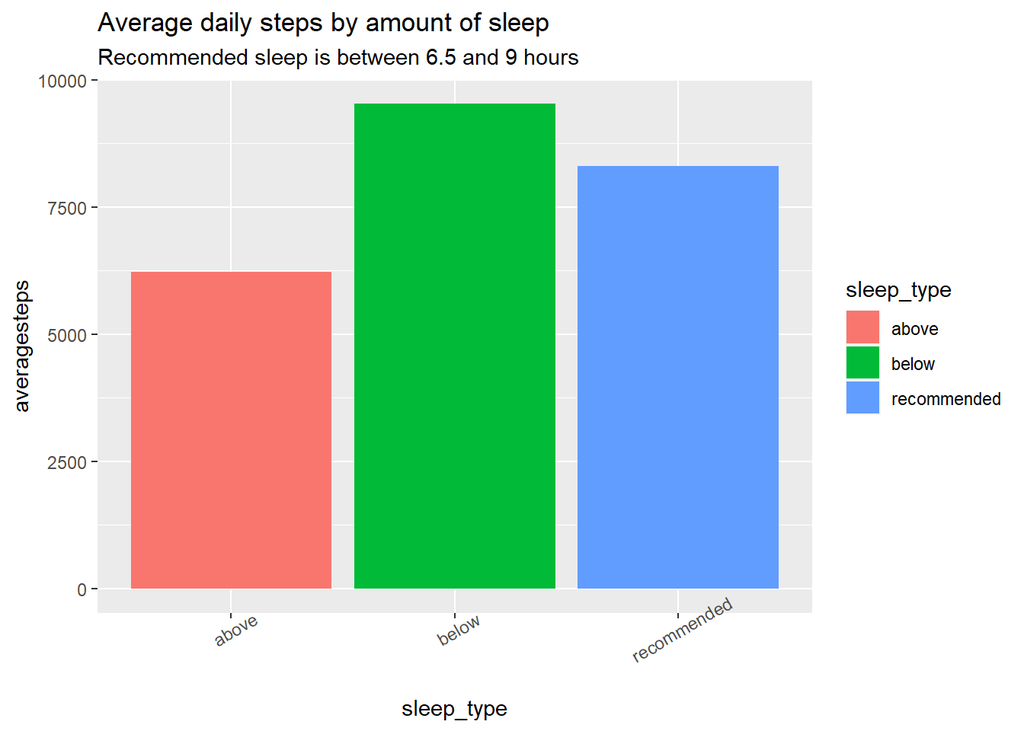

```r
avgsteps_by_sleeptype <- ggplot(sleep_type_summary) +
  geom_col(aes(x=sleep_type, y=averagesteps, fill = sleep_type)) +
  theme(axis.text.x = element_text(angle = 30)) +
  labs(title = "Average daily steps by amount of sleep",
       subtitle = "Recommended sleep is between 6.5 and 9 hours")
print(avgsteps_by_sleeptype)
```

Let’s check the scatterplot again, using different colors for the sleep_type

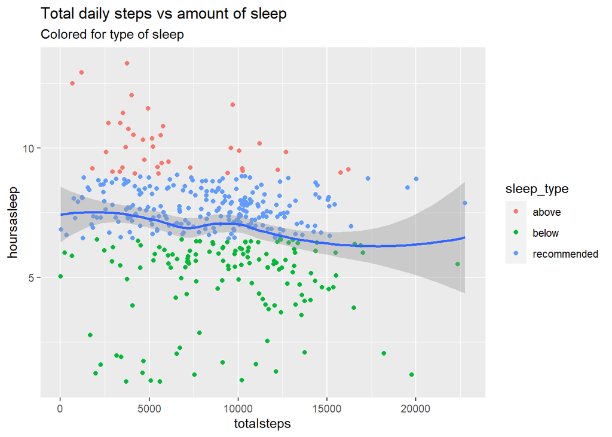

```r
steps_vs_sleep_group_col <- ggplot(daily_summary) + geom_point(mapping = aes(x = totalsteps, y = hoursasleep, color = sleep_type)) +
  geom_smooth(mapping = aes(x = totalsteps, y = hoursasleep))+
  labs(title = "Total daily steps vs amount of sleep", subtitle = "Colored for type of sleep")
print(steps_vs_sleep_group_col)
```

And then using facets to divide them

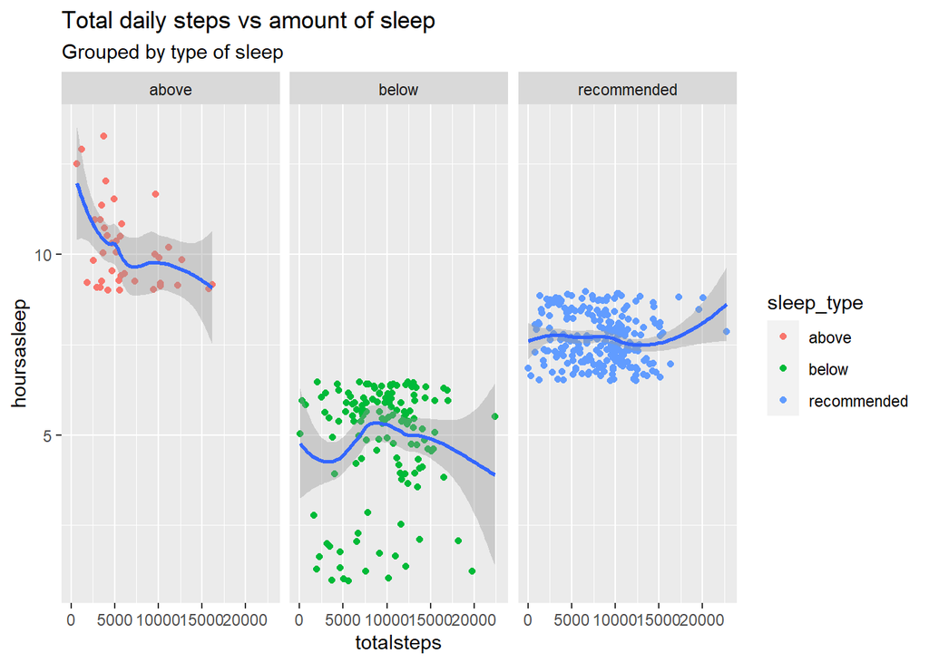

```r
steps_vs_sleep_group_fac <-ggplot(daily_summary) + geom_point(mapping = aes(x = totalsteps, y = hoursasleep, color = sleep_type)) +
  geom_smooth(mapping = aes(x = totalsteps, y = hoursasleep)) +
  facet_wrap(~sleep_type) +
  labs(title = "Total daily steps vs amount of sleep", subtitle = "Grouped by type of sleep")
print(steps_vs_sleep_group_fac)
```

## Definition of user categories

Another useful analysis could be identifying type of users by their average activity (steps), their average hours of sleep and their average calories.

```r
daily_average <- daily_summary %>%
  group_by(id) %>%
  summarise (mean_daily_steps = mean(totalsteps),
             mean_daily_calories = mean(calories), mean_daily_sleep = mean(hoursasleep))
```

Let’s assign some categories to the users based on these variables. Based on average steps, users will be sedentary (<6000), active (6000 >= x <=10000) or very active (>10000).

```r
daily_average <- daily_average %>%
  mutate(activity_lev = case_when(
    mean_daily_steps < 6000 ~ "Sedentary",
    mean_daily_steps >= 6000 & mean_daily_steps <= 10000 ~ "Active",
    mean_daily_steps > 10000 ~ "Very active"
  ))
```

The sleep categories could be the same used earlier, but these time they will apply to the average sleep for each ID and not to single observations.

```r
daily_average <- daily_average %>%
mutate(sleep_lev = case_when(
  mean_daily_sleep < 6.5 ~ "undersleeper",
  mean_daily_sleep >= 6.5 & mean_daily_sleep <= 9 ~ "adequate sleeper",
  mean_daily_sleep > 9 ~ "oversleeper"
))
```

It’s difficult to interpret data about calories without information about the age, weight, gender and job of the user. Therefore I prefer to focus on the other information. Let’s finally define the different user types by merging the coulumns.

```r
daily_average$user_type <- paste(daily_average$activity_lev, daily_average$sleep_lev, sep = " ")
```

I noticed that some of the users have a really low average amount of sleep. I want to investigate that further.

```r
daily_average %>%
  select(id, mean_daily_steps, mean_daily_sleep, user_type) %>%
  arrange(mean_daily_sleep) %>%
  print()
```

```
## # A tibble: 24 × 4
##            id mean_daily_steps mean_daily_sleep user_type
##         <dbl>            <dbl>            <dbl> <chr>
##  1 2320127002            5079              1.02 Sedentary undersleeper
##  2 7007744171            5116.             1.14 Sedentary undersleeper
##  3 4558609924            8139              2.13 Active undersleeper
##  4 3977333714           11218              4.89 Very active undersleeper
##  5 1644430081            7968.             4.9  Active undersleeper
##  6 8053475328           19079.             4.95 Very active undersleeper
##  7 4020332650            6597.             5.82 Active undersleeper
##  8 6775888955            3499              5.83 Sedentary undersleeper
##  9 1503960366           12406.             6.00 Very active undersleeper
## 10 4445114986            4756.             6.42 Sedentary undersleeper
## # ℹ 14 more rows
```

Three users sleep on average less then 2.5 hours per night. That seems quite odd. I will use their ID to check the single observations about their sleep, to make the data is not made misleading by some collection mistakes The IDs are 2320127002, 7007744171, 4558609924.

```r
daily_summary$id <- as.character(daily_summary$id)
count_id <- table(daily_summary$id)
print(count_id)
```

```
##
## 1503960366 1644430081 1844505072 1927972279 2026352035 2320127002 2347167796
##         25          4          3          5         28          1         15
## 3977333714 4020332650 4319703577 4388161847 4445114986 4558609924 4702921684
##         28          8         26         23         28          5         27
## 5553957443 5577150313 6117666160 6775888955 6962181067 7007744171 7086361926
##         31         26         18          3         31          2         24
## 8053475328 8378563200 8792009665
##          3         31         15
```

Out of the 24 users who shared sleep data, 8 have only 5 or less sleep observations. This is a serious obsatcle towards drawing meaningful conclusions about sleep, as an already small sample (remember: 24 is less than the standard minimun treshold of 30) has limited data for a third of the population in this variable.

The data about user types can be graphically represented like this.

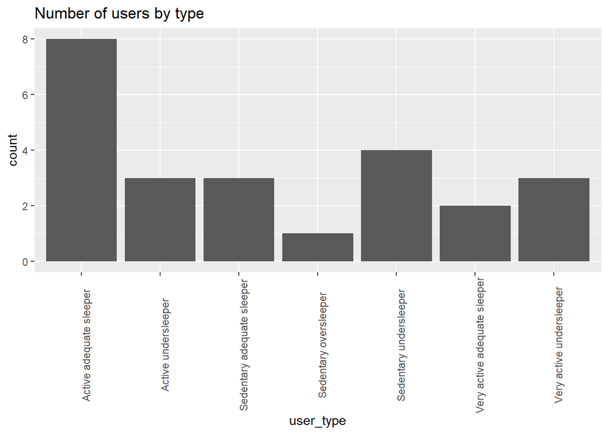

```r
count_users_type <- ggplot(daily_average) + geom_bar(aes(x=user_type))+
  theme(axis.text.x = element_text(angle = 90))+
  labs(title = "Number of users by type")
print(count_users_type)
```

**Unfortunately, due to the sampling issue stated before, this information is not statistically significant.**

I want therefore to define the user types only based on their activity level. I will use the original activity table for this, as the data is more complete than the data in daily_summary. I will create a summary of the activity based on the ID and then assign a user type

```r
activity_user <- activity %>%
  group_by(id) %>%
  summarise (avgsteps = mean(totalsteps),
             avgcalories = mean(calories),
             avgtotdistance = mean(totaldistance),
             time_avgveryactive= mean(veryactiveminutes),
             time_avgfairlyactive= mean(fairlyactiveminutes),
             time_avglightlyactive= mean(fairlyactiveminutes),
             time_avgsedentary= mean(sedentaryminutes))

activity_user <- activity_user %>%
  mutate(user_type = case_when(
    avgsteps < 6000 ~ "Sedentary",
    avgsteps >= 6000 & avgsteps <= 10000 ~ "Active",
    avgsteps > 10000 ~ "Very active"
  ))
```

Let’s use a bar chart to visualize the user type data

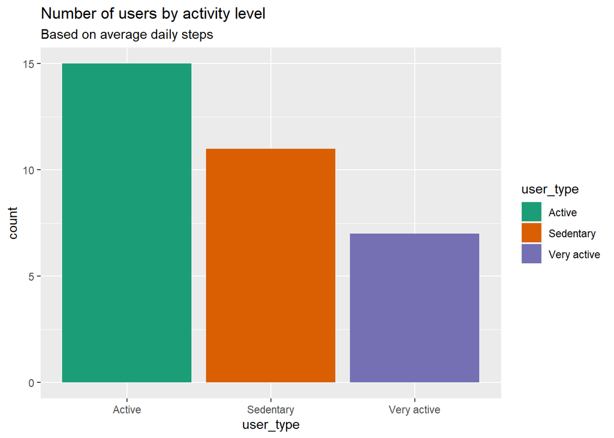

```r
count_users_activity <- ggplot(activity_user) +
  geom_bar(mapping = aes(x = user_type, fill= user_type)) +
  labs(title = "Number of users by activity level",
       subtitle = "Based on average daily steps") +
  scale_fill_brewer(palette="Dark2")
print(count_users_activity)
```

```r
count_user <- activity_user %>%
  count(user_type) %>%
  mutate(share_total = round(n/33, 3))
```

Out of 33 users: - 15 are active, the 46%; - 11 are sedentary, the 33%; - 7 are very active, the 21%.

###### Let’s now move on and carry out more analysis

## Change of amount of steps in time, by hours of the day and days of the week.

I want to analyze how the total steps change in time. Specifically, throughout the day and the week.

```r
hourly_average <- hourly_summary %>%
  group_by(time) %>%
  summarise(avgsteps = mean(steptotal), avgcalories = mean(calories),
            avgintensities =mean(totalintensity))
print(hourly_average)
```

```
## # A tibble: 24 × 4
##    time     avgsteps avgcalories avgintensities
##    <chr>       <dbl>       <dbl>          <dbl>
##  1 00:00:00    42.2         71.8          2.13
##  2 01:00:00    23.1         70.2          1.42
##  3 02:00:00    17.1         69.2          1.04
##  4 03:00:00     6.43        67.5          0.444
##  5 04:00:00    12.7         68.3          0.633
##  6 05:00:00    43.9         81.7          4.95
##  7 06:00:00   179.          87.0          7.77
##  8 07:00:00   306.          94.5         10.7
##  9 08:00:00   428.         103.          14.7
## 10 09:00:00   433.         106.          15.4
## # ℹ 14 more rows
```

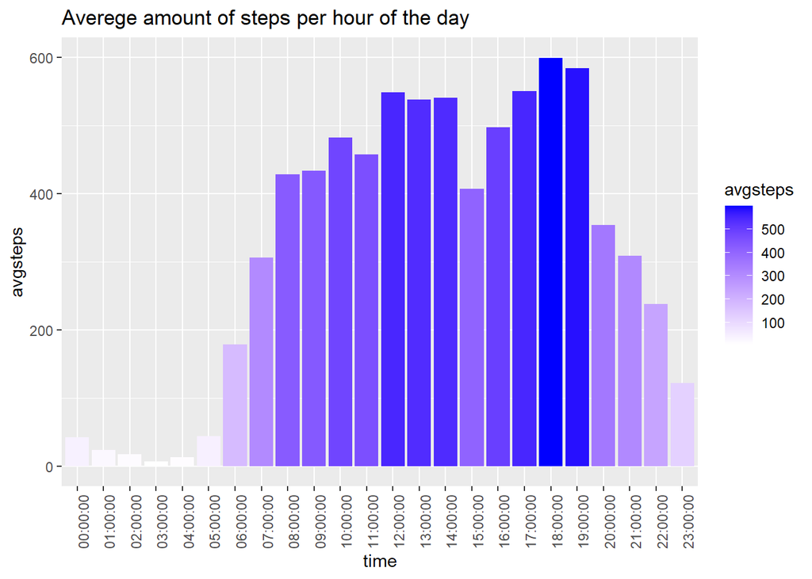

```r
steps_vs_hour <- ggplot(hourly_average) +
  geom_col(mapping = aes(x=time, y=avgsteps, fill=avgsteps)) +
  labs(title = "Averege amount of steps per hour of the day") +
  scale_fill_gradient(low = "white", high = "blue")+
  theme(axis.text.x = element_text(angle = 90))
print(steps_vs_hour)
```

The hours with the highest average steps seem to be the ones around lunchtime and the ones just after most offices close (17:00) and before dinner.

Before going further, I need to check something out. As my operative system doesn’t automatically refer to US standards for time related functions, I will make sure to change it.

```r
Sys.setlocale("LC_TIME", "English")
```

```
## [1] "English_United States.1252"
```

Let’s add weekday as a variable

```r
activity <- activity %>%
  mutate(weekday = weekdays(date))
```

Let’s create the summary table

```r
activities_weekday <- activity %>%
  select(id, date, weekday, totalsteps, calories) %>%
  group_by(weekday) %>%
  summarise(avgsteps = mean(totalsteps), avgcalories = mean(calories))
print(activities_weekday)
```

```
## # A tibble: 7 × 3
##   weekday   avgsteps avgcalories
##   <chr>        <dbl>       <dbl>
## 1 Friday       7448.       2332.
## 2 Monday       7781.       2324.
## 3 Saturday     8153.       2355.
## 4 Sunday       6933.       2263
## 5 Thursday     7406.       2200.
## 6 Tuesday      8125.       2356.
## 7 Wednesday    7559.       2303.
```

I don’t like the order the weekdays show up, which is alphabetical and does not make much sense. Let’s change it.

```r
custom_order <- c("Monday", "Tuesday", "Wednesday", "Thursday", "Friday", "Saturday", "Sunday")
activities_weekday <- activities_weekday[order(factor(activities_weekday$weekday, levels = custom_order)), ]
```

Let’s create the graph

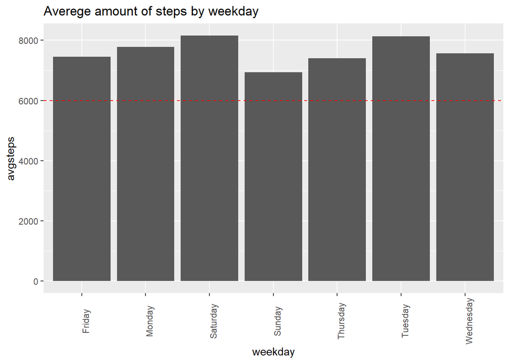

```r
steps_weekday <- ggplot(activities_weekday) +
  geom_col(mapping = aes(x=weekday, y=avgsteps)) +
  geom_hline(yintercept = 6000, linetype = "dashed", color = "red") +
  labs(title = "Averege amount of steps by weekday") +
  theme(axis.text.x = element_text(angle = 90))
print(steps_weekday)
```

All weekdays see average total steps higher than the minimum recommended amount of 6000.

**Sundays have the least average total steps. Probably becuase most people do not work nor go out. The company could launch a campaign to incentivize phisical activity on sundays.**

## Share of time spent doing activities at different intensity level, on average

As a last analysis, I would like to analyze how much time in a day users spend doing some kind of phisical activity, on average.

```r
activity_time <- activity_user %>%
  summarise(active = mean(time_avgveryactive),
            fairly_active = mean(time_avgfairlyactive),
            lightly_active = mean(time_avglightlyactive),
            sedentary = mean(time_avgsedentary),
            no_data = (1440 - active - fairly_active - lightly_active
                       - sedentary),
            sum = (active + fairly_active + lightly_active + sedentary + no_data),
            total_day = 24*60,
                      )
```

I want to calculate the same data in hours and as a precentage of the total. Before doing that, I want to turn the data from wide to long, to make it easier to manipulate it.

```r
activity_long <- gather(activity_time, key = "variable", value = "minutes")
print(activity_long)
```

```
## # A tibble: 7 × 2
##   variable       minutes
##   <chr>            <dbl>
## 1 active            20.3
## 2 fairly_active     13.3
## 3 lightly_active    13.3
## 4 sedentary        999.
## 5 no_data          394.
## 6 sum             1440
## 7 total_day       1440
```

```r
remove(activity_time)
```

Let’s now add the new columns.

```r
activity_long <- activity_long %>%
  mutate(hours = minutes/60, percentage = (minutes/1440)*100)
```

The variables sum and total_day were added to check that the calculations are correct. After making sure they are, I can remove them.

```r
activity_long <- activity_long[-6, ]
activity_long <- activity_long[-6, ]
```

**The Bellabeat product Leaf is particularly comfortable to wear compared to other smart devices, so the marketing for this product could be focused on that.**

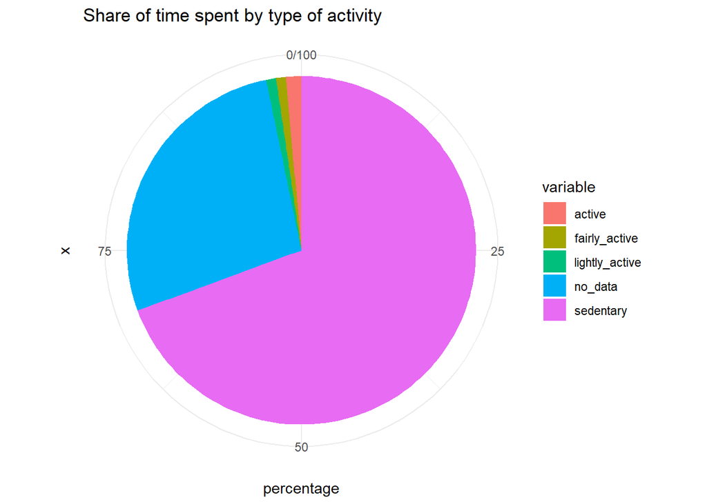

```r
pie_time_activity <- ggplot(activity_long, aes(x = "", y = percentage, fill = variable)) +
  geom_bar(stat = "identity", width = 1) +
  coord_polar(theta = "y") +
  labs(title = "Share of time spent by type of activity") +
  theme_minimal() +
  theme(legend.position = "right")
print(pie_time_activity)
```

# Sharing the insights

Analyzing the data allowed me to gather some interesting insight on how customers use smart devices and how Bellabeat’s marketing strategy could be improved.

But before diving into possible actions the company could take, let’s summarize the main findings.

Normally this would be done through tools like power point presentations, but for this project I will just create a new section in this same document.

### Sleep VS Steps reletionship

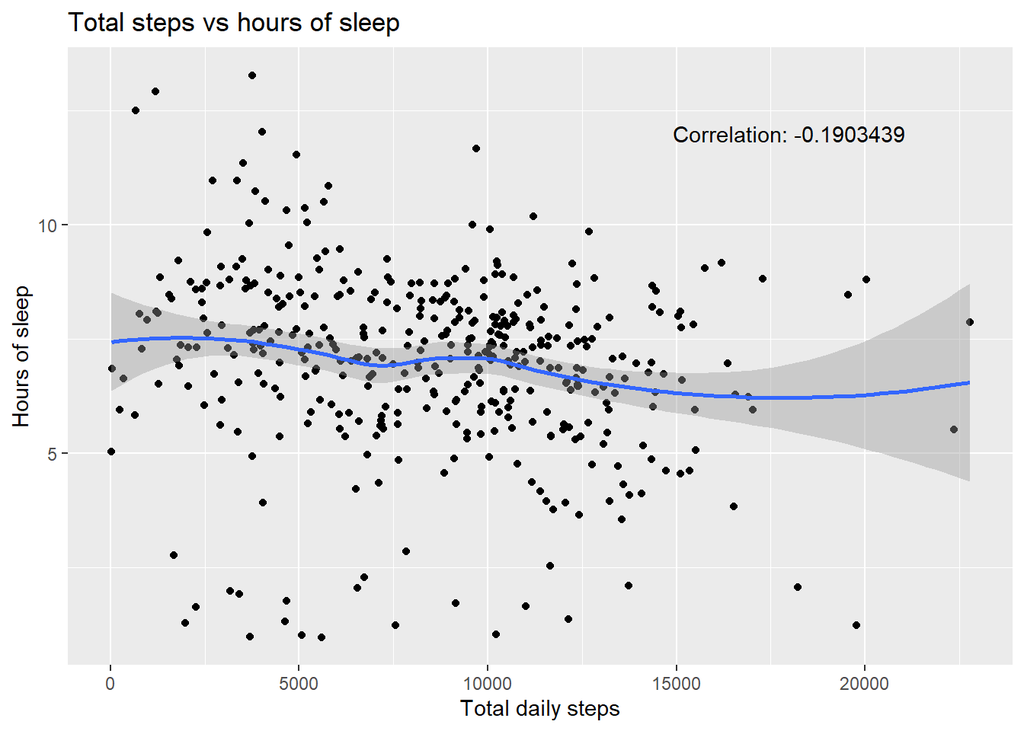

```r
steps_vs_sleep +
  annotate("text", x= 18000, y= 12,5, label = "Correlation: -0.1903439") +
  labs(x= "Total daily steps", y = "Hours of sleep")
```

After exluding a positive relationship between total hours of sleep and total daily steps, I divided the observations in three categories based on the recommended amount of sleep, that is between 6.5 and 9 hours a day.

```r
print(sleep_type_summary)
```

```
## # A tibble: 3 × 4
##   sleep_type  correlation averagesteps averagesleep
##   <chr>             <dbl>        <dbl>        <dbl>
## 1 below            0.0902        9532.         4.89
## 2 recommended     -0.0698        8306.         7.67
## 3 above           -0.410         6226.        10.2
```

For observations above 9 hours of sleep, there is a strong negative correlation with daily total steps.

For observations between 6.5 and 9 hours of sleep and below 6.5 hours no strong correlation is shown, approximatively -0.07 and +0.09.

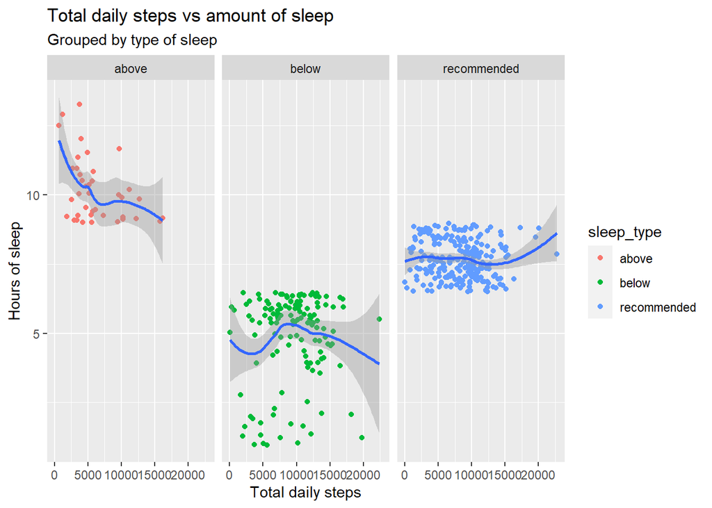

```r
steps_vs_sleep_group_fac +
  labs(x= "Total daily steps", y = "Hours of sleep")
```

Observations where the hours of sleep are less than the recommended amount have the highest amount of steps, on average.

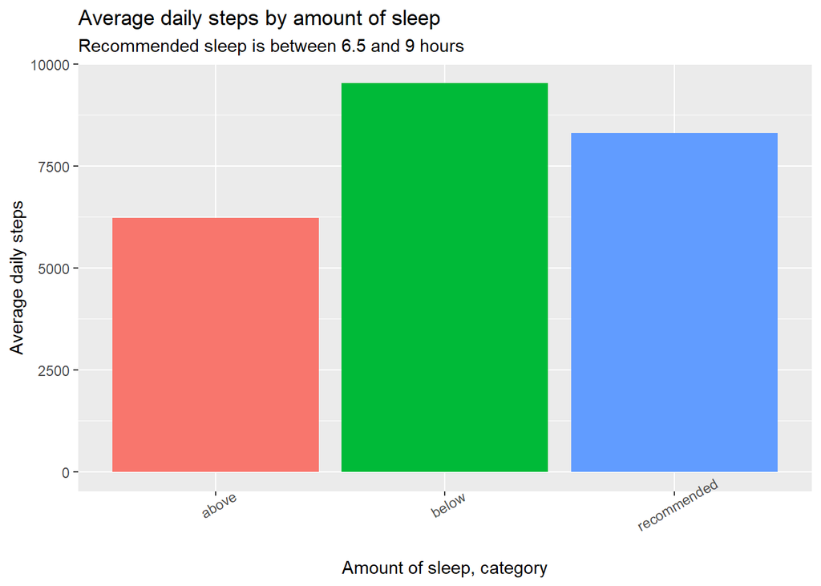

```r
avgsteps_by_sleeptype +
  labs(x= "Amount of sleep, category", y = "Average daily steps")+
  theme(legend.position = "none")
```

I also calculated how many of the total sleep observations fall in each group.

```r
print(count_sleep)
```

```
##    sleep_type   n share_total
## 1       above  39       0.095
## 2       below 136       0.332
## 3 recommended 235       0.573
```

### Definition and count of user categories

After creating user categories based on their average amount of sleep and average amount of steps, I had to take a step back do to the poor quality of the sleep related data.

I decided to define user categories based on their average amount steps only.

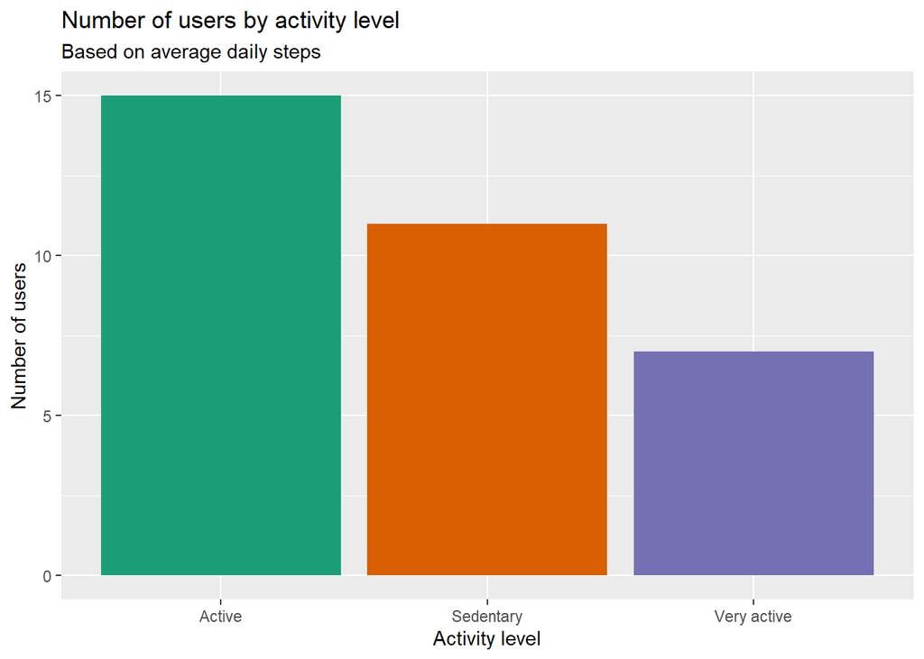

```r
count_users_activity +
  theme(legend.position = "none")+
  labs(x = "Activity level", y = "Number of users")
```

```r
print(count_user)
```

```
## # A tibble: 3 × 3
##   user_type       n share_total
##   <chr>       <int>       <dbl>
## 1 Active         15       0.455
## 2 Sedentary      11       0.333
## 3 Very active     7       0.212
```

Almost half of the users are active, with their average steps ranging between 6000 and 10000. A third is sedentary, taking on average less than 6000 steps a day. Around a fifth is very active, taking more than 10000 steps a day on average.

### Change of the amount of steps in time

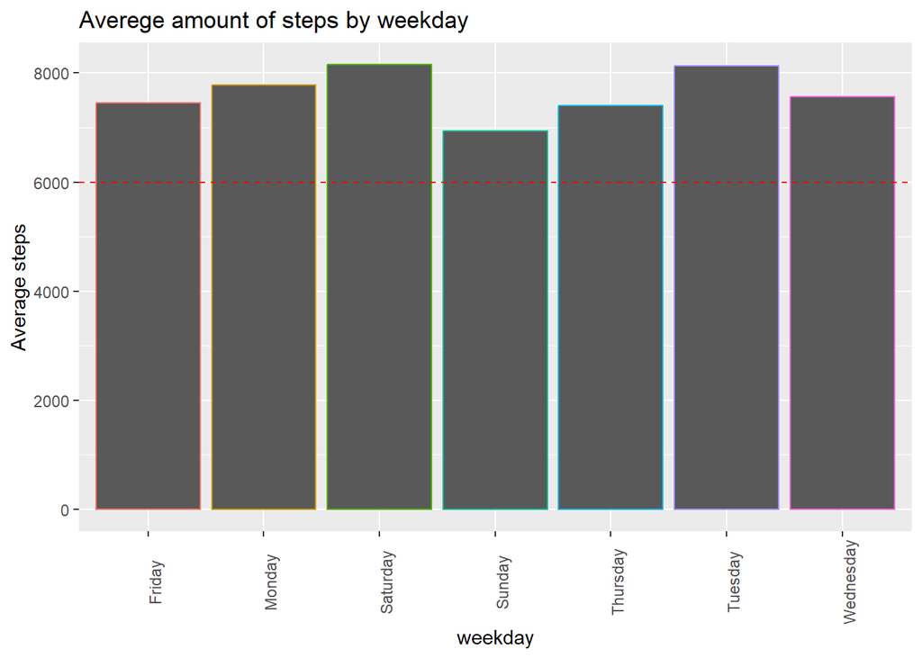

```r
steps_weekday +
  labs(y = "Average steps") +
  aes(color = weekday) +
  theme(legend.position = "none")
```

All weekdays see average total steps higher than the minimum recommended amount of 6000.

Sundays have the least average total steps.

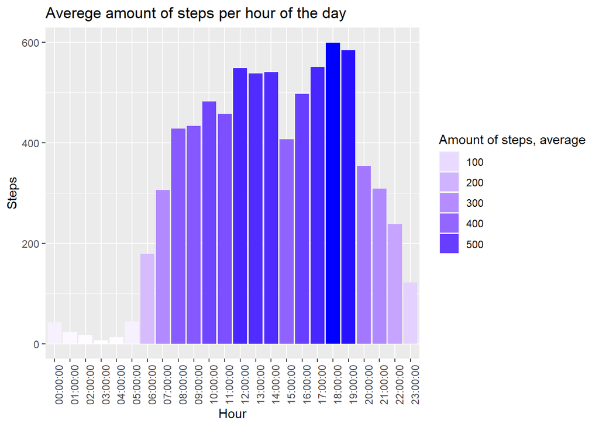

```r
steps_vs_hour+
  guides(fill=guide_legend(title="Amount of steps, average"))+
  labs(x= "Hour", y= "Steps")
```

The hours with the least steps taken on average are the ones from 22 to 6, when most people are at home and a lot of them sleep.

The peaks are from 12 to 14, when most people move to have lunch and from 17 to 19 when a lot of people finish working.

### Time spent on activities with given intensities.

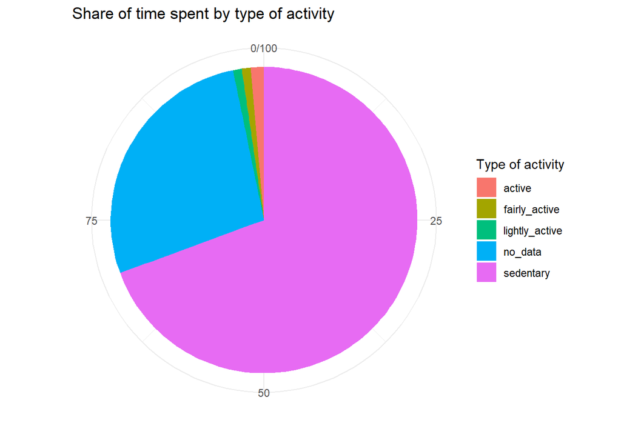

```r
pie_time_activity +
  labs(x= " ", y=" ") +
  guides(fill=guide_legend(title="Type of activity"))
```

```r
activity_long %>%
  select(variable, minutes, percentage) %>%
  print()
```

```
## # A tibble: 5 × 3
##   variable       minutes percentage
##   <chr>            <dbl>      <dbl>
## 1 active            20.3      1.41
## 2 fairly_active     13.3      0.921
## 3 lightly_active    13.3      0.921
## 4 sedentary        999.      69.4
## 5 no_data          394.      27.4
```

# Act on the findings

After defining the main findings, it is necessary to share some suggestions on how these insights could be interpreted and applied to make Bellabeat’s marketing strategy better.

Sundays have the least average total steps. Probably becuase a lot of people do not work nor go out. The company could launch a campaign to incentivize physical activity on sundays. This campaign could be focused on the Bellabeat App and lean on social aspects, as most people associate Sundays to family, friends and rest. The campaign could incentivize lightly active group activities.

- Explore your neighborhood and meet other people that live there;
- Go for a walk with your family;
- Stay fit with your friends;
- Local Bellabeat events every sunday (or e.g. every first sunday of the month).

The social aspect of the app could be enhanced and promoted.

A similar approach could be taken to incentivise physical activity in the morning, as average steps are particularly low at 6:00 and 7:00. As this time does not provide the opportunity to exploit the socialilty, the campaign should focus more on health and mindfulness.

One third of the users are sedentary, a reward-based marketing campaign could be launched to incentivize physical activity overall. Discounts or special content could be provided to users that satisfy set minimum requirement. An example could be winning a month of free premium subscription by waling more than 6000 steps for 5 days in a row.

The analysis could be expanded by using and joining more datasets and also by collecting data about Bellebeat users and possibly product-specigic data.